# Big Data Analytics Assessment 2

## Overview

Write Python code (especially PySpark where possible) to implement the tasks below (Please explain your code in detail in your report). Where appropriate, the output of code execution should be presented that relates to your answer to the tasks into your report, as the evidence of working program (e.g., screenshots). Output included without supporting explanation or interpretation will not receive credit. Where the tasks involve big data analytics with machine learning, you may need to formulate technical solution step by step, e.g., choose appropriate machine learning models / algorithms, justifying appropriateness of models/algorithms/techniques used, applying them in the context of the given task, and practising data visualisation techniques where appropriate. Test your solution and conduct experiments where appropriate. Evaluate the performance of implemented solution and analyse results where appropriate. Delve into deep technical explanations of the results and suggest possible improvement, etc. Make conclusions where appropriate. You need to present your solution to the tasks into a technical report. The report should be submitted onto Blackboard. Assignment tasks

### Assignment tasks

#### Part (I)

You will need to download the data file “Medical_info.csv” from the Blackboard. The dataset is about a study of factors predicting serum testosterone levels in a screened population in some country. The key to the variables in the dataset is explained in the table below. Please note there are null or missing values in some columns of the dataset.

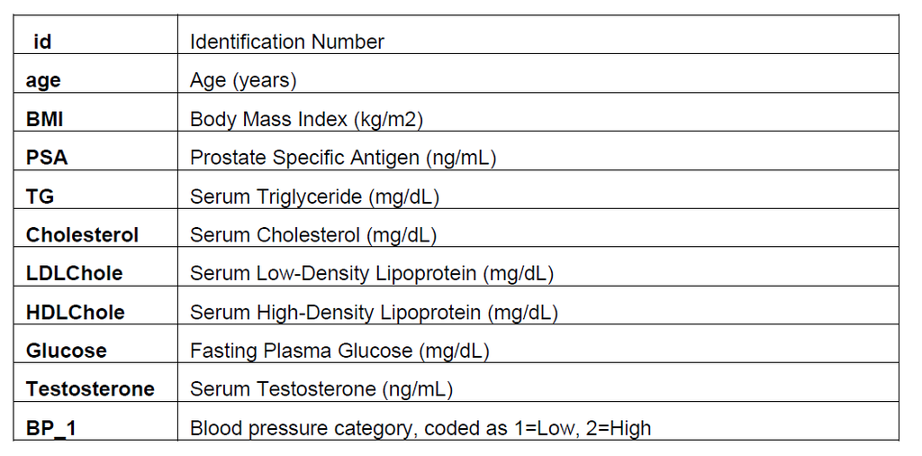

#### 1. Load the data file into a Spark DataFrame (1st DataFrame). Describe the structure of the DataFrame. (3 marks)

```python
# Initializing findspark to find our pyspark library location
import findspark
findspark.init()
```

```python
# Find Pyspark
import pyspark
findspark.find()
```

```
'C:\\bigdata\\spark3'
```

```python
# Import Pyspark Library and create spark session
from pyspark.sql import SparkSession
```

```python
spark = SparkSession \
    .builder \
    .appName("Creating Spark Session") \
    .getOrCreate()
```

```python
# Creating Dataframe for the csv file Medical_info
df = spark.read.csv('Medical_info.csv', header=True, inferSchema=True)
```

```python
#Showing Columns along with their datatypes
df.printSchema()
```

```
root
 |-- id: integer (nullable = true)
 |-- age: integer (nullable = true)
 |-- BMI: double (nullable = true)
 |-- PSA: string (nullable = true)
 |-- TG: integer (nullable = true)
 |-- Cholesterol: string (nullable = true)
 |-- LDLChole: integer (nullable = true)
 |-- HDLChole: integer (nullable = true)
 |-- Glucose: string (nullable = true)
 |-- Testosterone: double (nullable = true)
 |-- BP_1: integer (nullable = true)
```

```python
#Showing first 5 rows of dataframe
df.show(5)
```

```
+--------+---+------+---+---+-----------+--------+--------+-------+------------+----+
|      id|age|   BMI|PSA| TG|Cholesterol|LDLChole|HDLChole|Glucose|Testosterone|BP_1|
+--------+---+------+---+---+-----------+--------+--------+-------+------------+----+
|19782173| 59|28.378|.34|204|        196|     132|      49|     92|         7.7|   1|
|32613511| 59|24.968|  1|147|        181|     129|      34|     96|        4.09|   1|
|32723850| 48|31.307|.62|155|        185|     127|      41|    139|         4.5|   1|
|22913531| 47|27.837|.38|488|        254|     158|      55|    250|         5.3|   2|
|32628551| 55|22.662|.49| 87|        175|     120|      44|     99|         6.9|   1|
+--------+---+------+---+---+-----------+--------+--------+-------+------------+----+
only showing top 5 rows
```

```python
#Showing number of rows in the dataset
df.count()
```

```
6967
```

#### 2. Create a new DataFrame (2nd DataFrame) by removing all the rows with null/missing values in the 1st DataFrame and calculate the number of rows removed. (3 marks)

```python
# Calling col from pyspark to help change datatype of some columns
from pyspark.sql.functions import col
```

```python
# Changing datatype from string to float
df = df.withColumn('PSA',col('PSA').cast('float'))
# Changing datatype from string to int
df = df.withColumn('Glucose',col('Glucose').cast('int'))
# Changing datatype from string to int
df = df.withColumn('Cholesterol',col('Cholesterol').cast('int'))
```

```python
df1 = df.na.drop() # Removing rows with missing values
df1.count() # Counting number of rows after removing rows with null values
```

```
6909
```

```python
# Calculating number of rows removed
diff = df.count() - df1.count()
print("Number of Rows Removed = ",diff)
```

```
Number of Rows Removed =  58
```

#### 3. Calculate summary statistics of the ‘age’ feature in the 2nd DataFrame, including its min value, max value, mean value, median value, variance and standard deviation. Generate a histogram for the ‘age’ feature and describe the distribution of the feature. (3 marks)

```python
# Showing summary statistics of 'age' feature
df1.select('age').summary().show()
```

```
+-------+------------------+
|summary|               age|
+-------+------------------+
|  count|              6909|
|   mean|53.340715009408015|
| stddev| 8.712714893790364|
|    min|                21|
|    25%|                48|
|    50%|                53|
|    75%|                59|
|    max|                90|
+-------+------------------+
```

```python
# Importing visualization libraries
import seaborn as sns
import pandas as pd
import matplotlib.pyplot as plt
%matplotlib inline
```

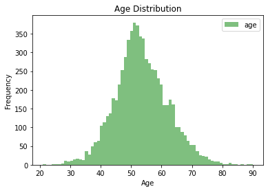

```python
df_his = df1.select('age').toPandas()
ax = df_his.plot.hist(bins=70, alpha=0.5, title='Age Distribution', color = 'green')
ax.set_xlabel("Age")
```

##### Histogram Description:

Based on the result we can see that the data is relatively normally distributed and the number of people with age around 52 has the highest number of count.

#### 4. Display the quartile info of the ‘BMI’ feature in the 2nd DataFrame. Generate a boxplot for the ‘BMI’ feature and discuss the distribution of the feature based on the boxplot. (3 marks)

```python
# Converting pyspark df to pandas df
df_bmi = df1.select('BMI').toPandas()
# Calculating lower, median and upper quartile range of bmi
df_bmi.quantile([0.25,0.5,0.75])
```

|  | BMI |
| --- | --- |
| 0.25 | 22.975 |
| 0.50 | 24.704 |
| 0.75 | 26.435 |

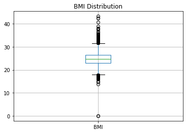

```python
plt.title("BMI Distribution")
df_bmi.boxplot(column=['BMI'],vert=True)
plt.show()
```

#### Boxplot description

The boxplot below shows the most of the values of BMI lies in the interquartile range, the median of BMI is arround 24-25. The lowerquartile is around 23 and the upper quartile is around 26. There seems to be quite a few outliers as well.

#### 5. Use Spark DataFrame API (i.e., expression methods) to count the number of rows where ‘age’ is greater than 50 and ‘BP_1’ equals 1. (3 marks)

```python
# Filterting dataframe to filter age > 50 and BP_1 = 1
df1_fil = df1.filter((df.age>50) & (df.BP_1 ==1))
```

```python
# Counting number of rows after filteration
df1_fil.count()
```

```
2166
```

#### 6. Use the ‘BP_1’ feature in the 2nd DataFrame as the target label, to build two classification models based on all other columns as predictors. Conduct performance evaluation for the two models and make conclusions. (15 marks)

```python
# Calling necessary libraries for doing classification
from pyspark import SparkContext
from pyspark.sql import SQLContext
from pyspark.ml.classification import DecisionTreeClassifier
from pyspark.ml.evaluation import MulticlassClassificationEvaluator
from pyspark.ml.feature import VectorAssembler
from sklearn.metrics import confusion_matrix
```

```python
# Creating features/predictors dataframe excluding BP_1
features = df1.drop('BP_1')
```

```python
# Using vectorassembler to convert features dataframe into a single vectorized column
va = VectorAssembler(inputCols = features.columns[:], outputCol='features')
```

```python
# Renaming BP_1 to label for better understanding
df1 = df1.withColumnRenamed("BP_1","label")
df1.show(2)
```

```
+--------+---+------+----+---+-----------+--------+--------+-------+------------+-----+
|      id|age|   BMI| PSA| TG|Cholesterol|LDLChole|HDLChole|Glucose|Testosterone|label|
+--------+---+------+----+---+-----------+--------+--------+-------+------------+-----+
|19782173| 59|28.378|0.34|204|        196|     132|      49|     92|         7.7|    1|
|32613511| 59|24.968| 1.0|147|        181|     129|      34|     96|        4.09|    1|
+--------+---+------+----+---+-----------+--------+--------+-------+------------+-----+
only showing top 2 rows
```

```python
# Creating a dataframe Merging vectorized features and target
va_df = va.transform(df1)
va_df = va_df.select(['features', 'label'])
va_df.show(3)
```

```
+--------------------+-----+
|            features|label|
+--------------------+-----+
|[1.9782173E7,59.0...|    1|
|[3.2613511E7,59.0...|    1|
|[3.272385E7,48.0,...|    1|
+--------------------+-----+
only showing top 3 rows
```

```python
# Doing test train split of the dataframe in the ratio 80% train and 20% test
(train, test) = va_df.randomSplit([0.8, 0.2])
```

##### 1. Decision Tree

```python
# Creating Decision Tree Classification Model and Training
# the model using train dataset
dtc = DecisionTreeClassifier(featuresCol="features",
                             labelCol="label")
dtc = dtc.fit(train)
```

```python
# Making Predictions using the trained model
pred = dtc.transform(test)
pred.show(3)
```

```
+--------------------+-----+-----------------+--------------------+----------+
|            features|label|    rawPrediction|         probability|prediction|
+--------------------+-----+-----------------+--------------------+----------+
|[1.0544583E7,59.0...|    1|[0.0,115.0,181.0]|[0.0,0.3885135135...|       2.0|
|[1.0562916E7,60.0...|    2|[0.0,246.0,418.0]|[0.0,0.3704819277...|       2.0|
|[1.0610574E7,47.0...|    1|[0.0,592.0,400.0]|[0.0,0.5967741935...|       1.0|
+--------------------+-----+-----------------+--------------------+----------+
only showing top 3 rows
```

```python
# Calculating the accuracy of the model
evaluator=MulticlassClassificationEvaluator(predictionCol="prediction")
acc = evaluator.evaluate(pred)
print("Prediction Accuracy: " ,round(acc*100,2))
```

```
Prediction Accuracy:  59.83
```

```python
# Creating a confusion matrix to see number of TP,TF, FP and FN
y_pred=pred.select("prediction").collect()
y_orig=pred.select("label").collect()
cm = confusion_matrix(y_orig, y_pred)
print("Confusion Matrix:")
print(cm)
```

```
Confusion Matrix:
[[540 229]
 [307 274]]
```

##### 2. Random Forest

```python
# Calling libraries to apply Randomforest classification
from pyspark.ml import Pipeline
from pyspark.ml.classification import RandomForestClassifier
from pyspark.ml.feature import IndexToString, StringIndexer, VectorIndexer
```

```python
# Fit on whole dataset to include all labels in index.
# A label indexer helps to map a string column of labels
# to an ML column of label indices.
labelIndexer = StringIndexer(inputCol="label",
                             outputCol="indexedLabel").fit(va_df)
```

```python
# Set maxCategories so features with > 4 distinct
# values are treated as continuous.
# Class for indexing categorical feature columns in a dataset of Vector.
# (Not needed in our cases but good practice)
featureIndexer = VectorIndexer(inputCol="features",
                outputCol="indexedFeatures", maxCategories=4).fit(va_df)
```

```python
# Train a RandomForest model.
rf = RandomForestClassifier(labelCol="label", featuresCol="features", numTrees=10)
```

```python
# IndexToString maps a column of label indices back to a column
# containing the original labels as strings.
labelConverter = IndexToString(inputCol="prediction", outputCol="predictedLabel",
                                labels=labelIndexer.labels)
```

```python
# Chain indexers and forest in a Pipeline
# A Pipeline chains multiple Transformers and Estimators
# together to specify an ML workflow.
pipeline = Pipeline(stages=[labelIndexer,
                            featureIndexer, rf, labelConverter])
```

```python
# Train model.
model = pipeline.fit(train)
```

```python
# Make predictions.
predictions = model.transform(test)
```

```python
# Check Prediction Accuracy
accuracy = evaluator.evaluate(predictions)
```

```python
print("Prediction Accuracy: ",round(accuracy*100,2))
```

```
Prediction Accuracy:  63.04
```

```python
# Create Confusion Matrix

y_pred=predictions.select("prediction").collect()
y_orig=predictions.select("label").collect()

cm = confusion_matrix(y_orig, y_pred)
print("Confusion Matrix:")
print(cm)
```

```
Confusion Matrix:
[[604 165]
 [319 262]]
```

### Evaluation of the Two Models:

On the basis of evaluation we can see that Random Forest did a slightly better job in making prediction compared to Decision Tree Classifier

### Part (II)

You will need to download the data file “Region_info.csv” from the Blackboard. The dataset provides information such as population size, average life expectancy, GDP per capita, and so on for some regions. The key to the variables in the dataset is explained in the table below.

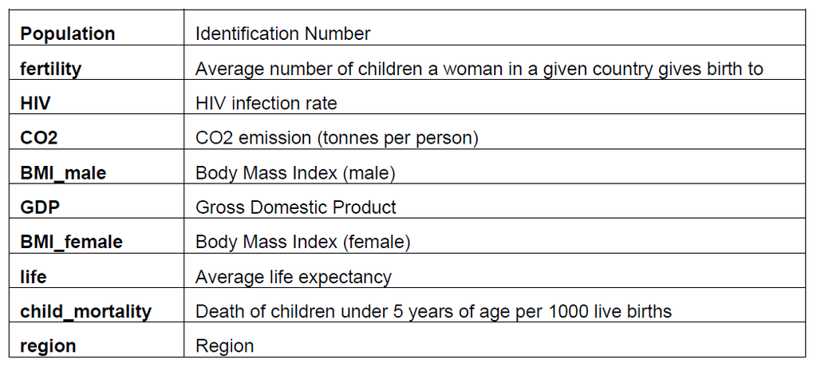

#### 1. Load the data file into a Spark DataFrame (1st DataFrame). Describe the structure of the created data frame. (3 marks)

```python
# Creating daframe of csv file Region_info
df_region = spark.read.csv('Region_info.csv', header=True, inferSchema=True)
```

```python
#Showing Columns along with their datatypes
df_region.printSchema()
```

```
root
 |-- population: double (nullable = true)
 |-- fertility: double (nullable = true)
 |-- HIV: double (nullable = true)
 |-- CO2: double (nullable = true)
 |-- BMI_male: double (nullable = true)
 |-- GDP: double (nullable = true)
 |-- BMI_female: double (nullable = true)
 |-- life: double (nullable = true)
 |-- child_mortality: double (nullable = true)
 |-- Region: string (nullable = true)
```

```python
#Showing first 5 rows
df_region.show(5)
```

```
+-----------+---------+---+------------------+--------+-------+----------+----+---------------+--------------------+
| population|fertility|HIV|               CO2|BMI_male|    GDP|BMI_female|life|child_mortality|              Region|
+-----------+---------+---+------------------+--------+-------+----------+----+---------------+--------------------+
|3.4811059E7|     2.73|0.1| 3.328944661018629| 24.5962|12314.0|  129.9049|75.3|           29.5|Middle East & Nor...|
|1.9842251E7|     6.43|2.0|1.4743533878509398|22.25083| 7103.0|  130.1247|58.3|          192.0|  Sub-Saharan Africa|
| 4.038186E7|     2.24|0.5|  4.78516998252535| 27.5017|14646.0|  118.8915|75.5|           15.4|             America|
|  2975029.0|      1.4|0.1|   1.8041062172001|25.35542| 7383.0|  132.8108|72.5|           20.0|Europe & Central ...|
|2.1370348E7|     1.96|0.1|  18.0163132681972|27.56373|41312.0|  117.3755|81.5|            5.2| East Asia & Pacific|
+-----------+---------+---+------------------+--------+-------+----------+----+---------------+--------------------+
only showing top 5 rows
```

```python
#Showing number of rows in the dataset
df_region.count()
```

```
139
```

#### 2. Create a new DataFrame (2nd DataFrame) by removing the ‘region’ column. (3 marks)

```python
# Creating new df without Region column
df_region2 = df_region.drop('Region')
```

```python
df_region2.show(2)
```

```
+-----------+---------+---+------------------+--------+-------+----------+----+---------------+
| population|fertility|HIV|               CO2|BMI_male|    GDP|BMI_female|life|child_mortality|
+-----------+---------+---+------------------+--------+-------+----------+----+---------------+
|3.4811059E7|     2.73|0.1| 3.328944661018629| 24.5962|12314.0|  129.9049|75.3|           29.5|
|1.9842251E7|     6.43|2.0|1.4743533878509398|22.25083| 7103.0|  130.1247|58.3|          192.0|
+-----------+---------+---+------------------+--------+-------+----------+----+---------------+
only showing top 2 rows
```

#### 3. Use a graph, explore and describe the relationship between ‘fertility’ feature and ‘life’ feature in the 2nd DataFrame. (3 marks)

```python
# Converting pyspark df to pandas df
df_region_pd = df_region2.toPandas()
```

```python
df_region_pd.head()
```

|  | population | fertility | HIV | CO2 | BMI_male | GDP | BMI_female | life | child_mortality |
| --- | --- | --- | --- | --- | --- | --- | --- | --- | --- |
| 0 | 34811059.0 | 2.73 | 0.1 | 3.328945 | 24.59620 | 12314.0 | 129.9049 | 75.3 | 29.5 |
| 1 | 19842251.0 | 6.43 | 2.0 | 1.474353 | 22.25083 | 7103.0 | 130.1247 | 58.3 | 192.0 |
| 2 | 40381860.0 | 2.24 | 0.5 | 4.785170 | 27.50170 | 14646.0 | 118.8915 | 75.5 | 15.4 |
| 3 | 2975029.0 | 1.40 | 0.1 | 1.804106 | 25.35542 | 7383.0 | 132.8108 | 72.5 | 20.0 |
| 4 | 21370348.0 | 1.96 | 0.1 | 18.016313 | 27.56373 | 41312.0 | 117.3755 | 81.5 | 5.2 |

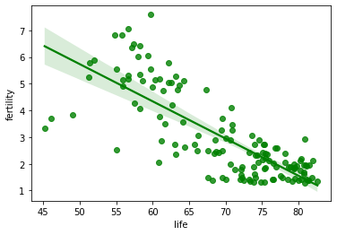

```python
# Creating Regressionplot to see the correlation between fertility and life
sns.regplot(x="life", y="fertility", data=df_region_pd, color = 'green')
```

#### Relationship:

We can see from the graph that there is a negative correlation between fertility and life. As age span increases, we can clearly see the fertility decreases.

#### 4. Use Spark SQL query to display the ‘fertility’ and ‘life’ columns in the 2nd DataFrame where ‘fertility’ is great than 1.0 and ‘life’ is greater than 70. (3 marks)

```python
df_region2.registerTempTable('temp_table')
df_query = spark.sql('SELECT fertility,life FROM temp_table WHERE fertility > 1.0 AND life > 70')
df_query.show(5)
```

```
+---------+----+
|fertility|life|
+---------+----+
|     2.73|75.3|
|     2.24|75.5|
|      1.4|72.5|
|     1.96|81.5|
|     1.41|80.4|
+---------+----+
only showing top 5 rows
```

#### 5. Build a linear regression model to predict life expectancy (the ‘life’ column) in the 2nd DataFrame using the ‘fertility’ column as the predictor. Conduct performance evaluation for the model and make conclusions. (9 marks)

```python
# Creating Vector Assembler
va2 = VectorAssembler(inputCols = ['fertility'], outputCol='features')
```

```python
# Creating New dataframe with target and features
va_df2 = va2.transform(df_region2)
va_df2 = va_df2.select(['features', 'life'])
va_df2.show(5)
```

```
+--------+----+
|features|life|
+--------+----+
|  [2.73]|75.3|
|  [6.43]|58.3|
|  [2.24]|75.5|
|   [1.4]|72.5|
|  [1.96]|81.5|
+--------+----+
only showing top 5 rows
```

```python
# Splitting the dataset in the ratio 70:30
(train_df, test_df) = va_df2.randomSplit([0.7, 0.3])
```

```python
# Calling Linear Regression Libraries
from pyspark.ml.regression import LinearRegression
from pyspark.ml.evaluation import RegressionEvaluator
```

```python
# Creating Regression Model and fitting Train dataset into the model
reg = LinearRegression(featuresCol = 'features', labelCol='life', maxIter=10 \
                       , regParam=0.3, elasticNetParam=0.8)
reg_model = reg.fit(train_df)
```

```python
# Making Predictions using the trained dataset
prediction = reg_model.transform(test_df)
prediction.show(5)
```

```
+--------+----+-----------------+
|features|life|       prediction|
+--------+----+-----------------+
|  [1.33]|75.3| 76.5662740358455|
|  [1.36]|79.2| 76.4386260074736|
|  [1.37]|80.0|76.39607666468297|
|  [1.42]|70.1| 76.1833299507298|
|  [1.42]|72.0| 76.1833299507298|
+--------+----+-----------------+
only showing top 5 rows
```

```python
# Evaluating Training Model Performance
trainSummary = reg_model.summary
print("RMSE: %f" % trainSummary.rootMeanSquaredError)
print("r2: %f" %trainSummary.r2)
```

```
RMSE: 5.901884
r2: 0.571316
```

```python
# Evaluating Prediction Model Performance
test_result = reg_model.evaluate(test_df)
print("RMS test = %g" % test_result.rootMeanSquaredError)
print("r2 test = %g" % test_result.r2)
```

```
RMS test = 4.3845
r2 test = 0.780992
```

#### 6. Build a Lasso regression model to predict life expectancy (the ‘life column) in the 2nd DataFrame using all other columns as the predictor. Conduct performance evaluation for the model and make conclusions. (9 marks)

```python
# Using Vector Assembler to vectorize features into a single column
features2 = df_region2.drop('life')
va3 = VectorAssembler(inputCols = features2.columns[:], outputCol='features')
```

```python
# Creating dataframe with target and features
va_df3 = va3.transform(df_region2)
va_df3 = va_df3.select(['features', 'life'])
va_df3.show(5)
```

```
+--------------------+----+
|            features|life|
+--------------------+----+
|[3.4811059E7,2.73...|75.3|
|[1.9842251E7,6.43...|58.3|
|[4.038186E7,2.24,...|75.5|
|[2975029.0,1.4,0....|72.5|
|[2.1370348E7,1.96...|81.5|
+--------------------+----+
only showing top 5 rows
```

```python
# Splitting the dataset in the ratio 70:30
(train_lasso, test_lasso) = va_df3.randomSplit([0.7, 0.3])
```

```python
from pyspark.ml.tuning import ParamGridBuilder, CrossValidator
```

```python
# Create initial LinearRegression model
lr = LinearRegression(labelCol="life", featuresCol="features")
```

```python
lrparamGrid = (ParamGridBuilder()
             .addGrid(lr.regParam, [0.01, 0.1, 0.5])
             .addGrid(lr.elasticNetParam, [1.0])
             .addGrid(lr.maxIter, [1, 5, 10])
             .build())
```

```python
# Evaluate model
lrevaluator = RegressionEvaluator(predictionCol="prediction",
                                  labelCol="life", metricName="rmse")
```

```python
# Create 5-fold CrossValidator
lrcv = CrossValidator(estimator = lr,
                    estimatorParamMaps = lrparamGrid,
                    evaluator = lrevaluator,
                    numFolds = 5)
```

```python
# Run cross validations
lrcvModel = lrcv.fit(train_lasso)
print(lrcvModel)
```

```
CrossValidatorModel_f8a8456e41d0
```

```python
# Use test set here so we can measure the accuracy of
# our model on new data
lrpredictions = lrcvModel.transform(test_lasso)
```

```python
# Viewing Performance of model in train
trainSummary_lasso = lrcvModel.bestModel.summary
print("RMSE: %f" % trainSummary_lasso.rootMeanSquaredError)
print("r2: %f" %trainSummary_lasso.r2)
```

```
RMSE: 2.840578
r2: 0.896932
```

```python
# Viewing Performance of model in test
test_result = lrcvModel.bestModel.evaluate(test_lasso)
print("RMSE test = %g" % test_result.rootMeanSquaredError)
print("r2 test = %g" % test_result.r2)
```

```
RMSE test = 3.30049
r2 test = 0.879745
```

#### Model Evaluation:

After performing lasso linear regression on our dataset by splitting the dataset in the ratio 70:30. We can see that we acheived RMSE of 2.84 on our training dataset where as we acheived a RMSE of 3.30 on our test dataset. Since the values of RMSE are relatively similar we can safely say that our model fit really well into the model, it maybe very slightly overfitted. As far as the r2 value is concerned, we can see that we acheived r2 of 0.89 on our train dataset whereas we attained r2 of 0.87 on our test dataset. This shows the performance of the lasso linear regression was much better than simple linear regression and we can easily see that taking multiple features into account when doing prediction analysis the performance of model can significantly improve

```python
# Ending Spark Session
pyspark.sql.SparkSession.stop
```

```
<function pyspark.sql.session.SparkSession.stop(self)>
```